# Prepare Remaining Data Sets: NY Citi Bike Dashboard Project

In this lesson and document we write the queries for preparing the three remaining aggregated data sets for the dashboard and add the data sources to Google Studio.

When viewing the dashboard,

[figure not shown]

we see that we need three more data sets:

1. Bike stats by date and by start station
2. Bike stats by date by Gender and by User type
3. Bike stats by date and by Bike ID

## Question 1: Prepare Bike stats by date and by start station

Using **`bigquery-public-data.new_york.citibike_trips`**, write a query which gives a table with the following columns/results:

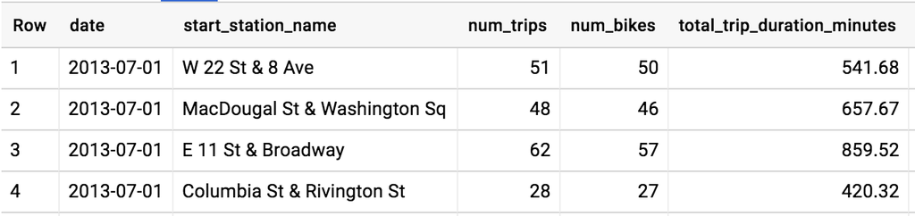

This is an aggregate with one record per date per start station name.

## Question 2: Prepare Bike stats by date by Gender and by User type

Using **`bigquery-public-data.new_york.citibike_trips`**, write a query which gives a table with the following columns/results:

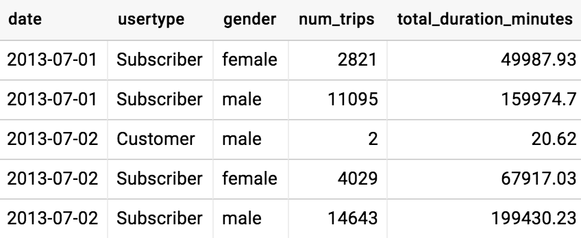

This is an aggregate with one record per date per gender per user type.

## Question 3: Prepare Bike stats by date and by Bike ID

Using **`bigquery-public-data.new_york.citibike_trips`**, write a query which gives a table with the following columns/results:

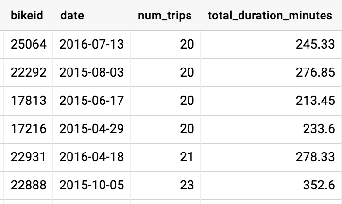

This is an aggregate with one record per date per bikeid.

## ANSWERS (SCROLL DOWN TO SEE)

## Answer 1:

- note: you do not need the **ORDER BY**

```sql
SELECT
  CAST(starttime AS date) AS date,
  start_station_name,
  COUNT(*) AS num_trips,
  COUNT(DISTINCT bikeid) AS num_bikes,
  ROUND(SUM(tripduration/60),2) AS total_trip_duration_minutes
FROM
  `bigquery-public-data.new_york.citibike_trips`
GROUP BY
  date,
  start_station_name
ORDER BY
  date
```

## Answer 2:

- note: you do not need the **ORDER BY**

```sql
SELECT
  CAST(starttime AS date) AS date,
  usertype,
  gender,
  COUNT(*) AS num_trips,
  ROUND(SUM(tripduration/60),2) AS total_duration_minutes
FROM
  `bigquery-public-data.new_york.citibike_trips`
WHERE
  gender != 'unknown'
GROUP BY
  date,
  usertype,
  gender
ORDER BY
  date,
  usertype,
  gender
```

## Answer 3:

```sql
SELECT
  bikeid,
  CAST(starttime AS date) AS date,
  COUNT(*) AS num_trips,
  round(SUM(tripduration/60),2) AS total_duration_minutes
FROM
  `bigquery-public-data.new_york.citibike_trips`
GROUP BY
  date,
  bikeid
```